# Google Capstone Project: Fitness tracker usage

## Data process and analysis section

## Import related libraries

```python
import pandas as pd
import numpy as np
import statsmodels.api as sm
import matplotlib.pyplot as plt
from sklearn.linear_model import LinearRegression
import datetime as dt
import seaborn as sns
sns.set()
```

## Import raw data

```python
raw_data = pd.read_csv('dailyActivity_merged.csv')
raw_data.head()
# preview dataset
```

|  | Id | ActivityDate | TotalSteps | TotalDistance | TrackerDistance | LoggedActivitiesDistance | VeryActiveDistance | ModeratelyActiveDistance | LightActiveDistance | SedentaryActiveDistance | VeryActiveMinutes | FairlyActiveMinutes | LightlyActiveMinutes | SedentaryMinutes | Calories |
| --- | --- | --- | --- | --- | --- | --- | --- | --- | --- | --- | --- | --- | --- | --- | --- |
| 0 | 1503960366 | 4/12/2016 | 13162 | 8.50 | 8.50 | 0.0 | 1.88 | 0.55 | 6.06 | 0.0 | 25 | 13 | 328 | 728 | 1985 |
| 1 | 1503960366 | 4/13/2016 | 10735 | 6.97 | 6.97 | 0.0 | 1.57 | 0.69 | 4.71 | 0.0 | 21 | 19 | 217 | 776 | 1797 |
| 2 | 1503960366 | 4/14/2016 | 10460 | 6.74 | 6.74 | 0.0 | 2.44 | 0.40 | 3.91 | 0.0 | 30 | 11 | 181 | 1218 | 1776 |
| 3 | 1503960366 | 4/15/2016 | 9762 | 6.28 | 6.28 | 0.0 | 2.14 | 1.26 | 2.83 | 0.0 | 29 | 34 | 209 | 726 | 1745 |
| 4 | 1503960366 | 4/16/2016 | 12669 | 8.16 | 8.16 | 0.0 | 2.71 | 0.41 | 5.04 | 0.0 | 36 | 10 | 221 | 773 | 1863 |

## Checking data: missing value, duplicated record

```python
raw_data.isnull().sum()
# no missing value
```

```
Id                          0
ActivityDate                0
TotalSteps                  0
TotalDistance               0
TrackerDistance             0
LoggedActivitiesDistance    0
VeryActiveDistance          0
ModeratelyActiveDistance    0
LightActiveDistance         0
SedentaryActiveDistance     0
VeryActiveMinutes           0
FairlyActiveMinutes         0
LightlyActiveMinutes        0
SedentaryMinutes            0
Calories                    0
dtype: int64
```

```python
duplicated_data = raw_data.duplicated()
duplicated_data.describe()
# no duplicated record
```

```
count       940
unique        1
top       False
freq        940
dtype: object
```

```python
cleaned_data = raw_data
```

## Modifying data type

```python
cleaned_data.info()
# Check the data type. Note that Id is "int" and ActivityDate is "object"
```

```
<class 'pandas.core.frame.DataFrame'>
RangeIndex: 940 entries, 0 to 939
Data columns (total 15 columns):
 #   Column                    Non-Null Count  Dtype
---  ------                    --------------  -----
 0   Id                        940 non-null    int64
 1   ActivityDate              940 non-null    object
 2   TotalSteps                940 non-null    int64
 3   TotalDistance             940 non-null    float64
 4   TrackerDistance           940 non-null    float64
 5   LoggedActivitiesDistance  940 non-null    float64
 6   VeryActiveDistance        940 non-null    float64
 7   ModeratelyActiveDistance  940 non-null    float64
 8   LightActiveDistance       940 non-null    float64
 9   SedentaryActiveDistance   940 non-null    float64
 10  VeryActiveMinutes         940 non-null    int64
 11  FairlyActiveMinutes       940 non-null    int64
 12  LightlyActiveMinutes      940 non-null    int64
 13  SedentaryMinutes          940 non-null    int64
 14  Calories                  940 non-null    int64
dtypes: float64(7), int64(7), object(1)
memory usage: 110.3+ KB
```

```python
# convert Id from "int" to "object" and convert ActivityDate from "object" to "datetime"
cleaned_data["ActivityDate"] = pd.to_datetime(cleaned_data["ActivityDate"], format ="%m/%d/%Y")
cleaned_data['Id'] = cleaned_data['Id'].astype('object')
cleaned_data.info()
```

```
<class 'pandas.core.frame.DataFrame'>
RangeIndex: 940 entries, 0 to 939
Data columns (total 15 columns):
 #   Column                    Non-Null Count  Dtype
---  ------                    --------------  -----
 0   Id                        940 non-null    object
 1   ActivityDate              940 non-null    datetime64[ns]
 2   TotalSteps                940 non-null    int64
 3   TotalDistance             940 non-null    float64
 4   TrackerDistance           940 non-null    float64
 5   LoggedActivitiesDistance  940 non-null    float64
 6   VeryActiveDistance        940 non-null    float64
 7   ModeratelyActiveDistance  940 non-null    float64
 8   LightActiveDistance       940 non-null    float64
 9   SedentaryActiveDistance   940 non-null    float64
 10  VeryActiveMinutes         940 non-null    int64
 11  FairlyActiveMinutes       940 non-null    int64
 12  LightlyActiveMinutes      940 non-null    int64
 13  SedentaryMinutes          940 non-null    int64
 14  Calories                  940 non-null    int64
dtypes: datetime64[ns](1), float64(7), int64(6), object(1)
memory usage: 110.3+ KB
```

```python
# preview data after modifying data type
cleaned_data.head()
```

|  | Id | ActivityDate | TotalSteps | TotalDistance | TrackerDistance | LoggedActivitiesDistance | VeryActiveDistance | ModeratelyActiveDistance | LightActiveDistance | SedentaryActiveDistance | VeryActiveMinutes | FairlyActiveMinutes | LightlyActiveMinutes | SedentaryMinutes | Calories |
| --- | --- | --- | --- | --- | --- | --- | --- | --- | --- | --- | --- | --- | --- | --- | --- |
| 0 | 1503960366 | 2016-04-12 | 13162 | 8.50 | 8.50 | 0.0 | 1.88 | 0.55 | 6.06 | 0.0 | 25 | 13 | 328 | 728 | 1985 |
| 1 | 1503960366 | 2016-04-13 | 10735 | 6.97 | 6.97 | 0.0 | 1.57 | 0.69 | 4.71 | 0.0 | 21 | 19 | 217 | 776 | 1797 |
| 2 | 1503960366 | 2016-04-14 | 10460 | 6.74 | 6.74 | 0.0 | 2.44 | 0.40 | 3.91 | 0.0 | 30 | 11 | 181 | 1218 | 1776 |
| 3 | 1503960366 | 2016-04-15 | 9762 | 6.28 | 6.28 | 0.0 | 2.14 | 1.26 | 2.83 | 0.0 | 29 | 34 | 209 | 726 | 1745 |
| 4 | 1503960366 | 2016-04-16 | 12669 | 8.16 | 8.16 | 0.0 | 2.71 | 0.41 | 5.04 | 0.0 | 36 | 10 | 221 | 773 | 1863 |

## Creating new variables of interest

```python
# create new variables for further analysis
cleaned_data["Day_of_Week"] = cleaned_data["ActivityDate"].dt.day_name()
cleaned_data["Total_Active_Minutes"] = cleaned_data["VeryActiveMinutes"] + cleaned_data["FairlyActiveMinutes"] + cleaned_data["LightlyActiveMinutes"] + cleaned_data["SedentaryMinutes"]
cleaned_data.head()
```

|  | Id | ActivityDate | TotalSteps | TotalDistance | TrackerDistance | LoggedActivitiesDistance | VeryActiveDistance | ModeratelyActiveDistance | LightActiveDistance | SedentaryActiveDistance | VeryActiveMinutes | FairlyActiveMinutes | LightlyActiveMinutes | SedentaryMinutes | Calories | Day_of_Week | Total_Active_Minutes |
| --- | --- | --- | --- | --- | --- | --- | --- | --- | --- | --- | --- | --- | --- | --- | --- | --- | --- |
| 0 | 1503960366 | 2016-04-12 | 13162 | 8.50 | 8.50 | 0.0 | 1.88 | 0.55 | 6.06 | 0.0 | 25 | 13 | 328 | 728 | 1985 | Tuesday | 1094 |
| 1 | 1503960366 | 2016-04-13 | 10735 | 6.97 | 6.97 | 0.0 | 1.57 | 0.69 | 4.71 | 0.0 | 21 | 19 | 217 | 776 | 1797 | Wednesday | 1033 |
| 2 | 1503960366 | 2016-04-14 | 10460 | 6.74 | 6.74 | 0.0 | 2.44 | 0.40 | 3.91 | 0.0 | 30 | 11 | 181 | 1218 | 1776 | Thursday | 1440 |
| 3 | 1503960366 | 2016-04-15 | 9762 | 6.28 | 6.28 | 0.0 | 2.14 | 1.26 | 2.83 | 0.0 | 29 | 34 | 209 | 726 | 1745 | Friday | 998 |
| 4 | 1503960366 | 2016-04-16 | 12669 | 8.16 | 8.16 | 0.0 | 2.71 | 0.41 | 5.04 | 0.0 | 36 | 10 | 221 | 773 | 1863 | Saturday | 1040 |

## Oversee dataset

```python
cleaned_data.describe()
```

|  | TotalSteps | TotalDistance | TrackerDistance | LoggedActivitiesDistance | VeryActiveDistance | ModeratelyActiveDistance | LightActiveDistance | SedentaryActiveDistance | VeryActiveMinutes | FairlyActiveMinutes | LightlyActiveMinutes | SedentaryMinutes | Calories | Total_Active_Minutes |
| --- | --- | --- | --- | --- | --- | --- | --- | --- | --- | --- | --- | --- | --- | --- |
| count | 940.000000 | 940.000000 | 940.000000 | 940.000000 | 940.000000 | 940.000000 | 940.000000 | 940.000000 | 940.000000 | 940.000000 | 940.000000 | 940.000000 | 940.000000 | 940.000000 |
| mean | 7637.910638 | 5.489702 | 5.475351 | 0.108171 | 1.502681 | 0.567543 | 3.340819 | 0.001606 | 21.164894 | 13.564894 | 192.812766 | 991.210638 | 2303.609574 | 1218.753191 |
| std | 5087.150742 | 3.924606 | 3.907276 | 0.619897 | 2.658941 | 0.883580 | 2.040655 | 0.007346 | 32.844803 | 19.987404 | 109.174700 | 301.267437 | 718.166862 | 265.931767 |
| min | 0.000000 | 0.000000 | 0.000000 | 0.000000 | 0.000000 | 0.000000 | 0.000000 | 0.000000 | 0.000000 | 0.000000 | 0.000000 | 0.000000 | 0.000000 | 2.000000 |
| 25% | 3789.750000 | 2.620000 | 2.620000 | 0.000000 | 0.000000 | 0.000000 | 1.945000 | 0.000000 | 0.000000 | 0.000000 | 127.000000 | 729.750000 | 1828.500000 | 989.750000 |
| 50% | 7405.500000 | 5.245000 | 5.245000 | 0.000000 | 0.210000 | 0.240000 | 3.365000 | 0.000000 | 4.000000 | 6.000000 | 199.000000 | 1057.500000 | 2134.000000 | 1440.000000 |
| 75% | 10727.000000 | 7.712500 | 7.710000 | 0.000000 | 2.052500 | 0.800000 | 4.782500 | 0.000000 | 32.000000 | 19.000000 | 264.000000 | 1229.500000 | 2793.250000 | 1440.000000 |
| max | 36019.000000 | 28.030001 | 28.030001 | 4.942142 | 21.920000 | 6.480000 | 10.710000 | 0.110000 | 210.000000 | 143.000000 | 518.000000 | 1440.000000 | 4900.000000 | 1440.000000 |

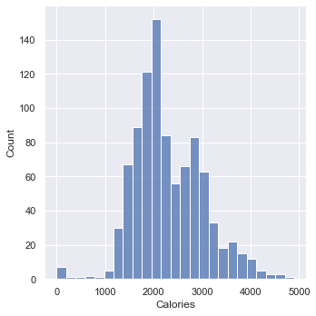

```python
sns.displot(cleaned_data['Calories'])
```

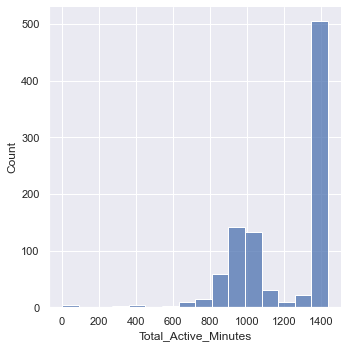

```python
sns.displot(cleaned_data['Total_Active_Minutes'])
```

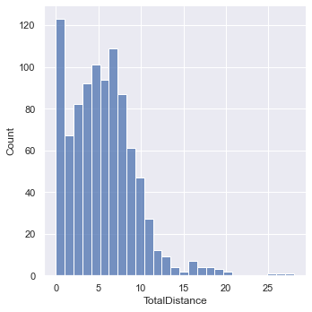

```python
sns.displot(cleaned_data['TotalDistance'])
```

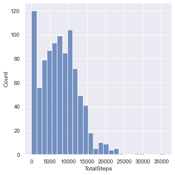

```python
sns.displot(cleaned_data['TotalSteps'])
```

The mean of recorded daily step is around 7638, far less than recommended 10000 daily step for general fitness (Centers for Disease Control and Prevention, https://www.cdc.gov/diabetes/prevention/pdf/postcurriculum_session8.pdf )

## Aggregating data group by ID

```python
# calculate the percentage of smart device usage
Aggregated_data_id = cleaned_data.groupby(['Id']).count().reset_index()
Aggregated_data_id['percentage_of_activity']=Aggregated_data_id['ActivityDate']/31
Count_activity=Aggregated_data_id[['Id','ActivityDate','percentage_of_activity']]
Count_activity.head()
```

|  | Id | ActivityDate | percentage_of_activity |
| --- | --- | --- | --- |
| 0 | 1503960366 | 31 | 1.000000 |
| 1 | 1624580081 | 31 | 1.000000 |
| 2 | 1644430081 | 30 | 0.967742 |
| 3 | 1844505072 | 31 | 1.000000 |
| 4 | 1927972279 | 31 | 1.000000 |

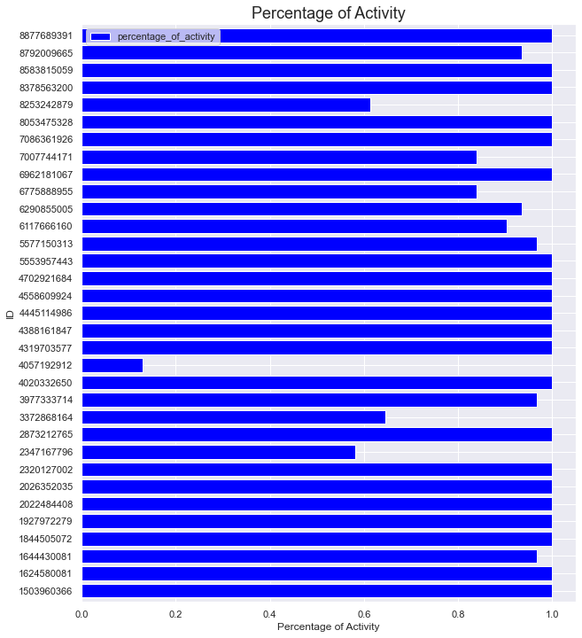

```python
active_percentage = Count_activity[['Id','percentage_of_activity']]
fig, ax = plt.subplots(figsize=(10, 12))
active_percentage.plot(x = 'Id',kind = 'barh',mark_right = True,color=['blue'],width=0.8,ax=ax)
plt.xlabel('Percentage of Activity', size=12)
plt.ylabel('ID', size=12)
plt.title('Percentage of Activity', size=18)
plt.legend(loc='upper left');
```

Most of the users tend to use APP to record their daily activity (Duration: 31 days).

1. 29/33 users recorded more than 80% of a month.
2. Only 1/33 user recorded less than 20%

```python
# calculate averaged daily step
Aggregated_data = cleaned_data.groupby(['Id']).mean().reset_index()
Aggregated_data.head()
```

|  | Id | TotalSteps | TotalDistance | TrackerDistance | LoggedActivitiesDistance | VeryActiveDistance | ModeratelyActiveDistance | LightActiveDistance | SedentaryActiveDistance | VeryActiveMinutes | FairlyActiveMinutes | LightlyActiveMinutes | SedentaryMinutes | Calories | Total_Active_Minutes |
| --- | --- | --- | --- | --- | --- | --- | --- | --- | --- | --- | --- | --- | --- | --- | --- |
| 0 | 1503960366 | 12116.741935 | 7.809677 | 7.809677 | 0.0 | 2.858387 | 0.794194 | 4.152903 | 0.000000 | 38.709677 | 19.161290 | 219.935484 | 848.161290 | 1816.419355 | 1125.967742 |
| 1 | 1624580081 | 5743.903226 | 3.914839 | 3.914839 | 0.0 | 0.939355 | 0.360645 | 2.606774 | 0.006129 | 8.677419 | 5.806452 | 153.483871 | 1257.741935 | 1483.354839 | 1425.709677 |
| 2 | 1644430081 | 7282.966667 | 5.295333 | 5.295333 | 0.0 | 0.730000 | 0.951000 | 3.609000 | 0.004000 | 9.566667 | 21.366667 | 178.466667 | 1161.866667 | 2811.300000 | 1371.266667 |
| 3 | 1844505072 | 2580.064516 | 1.706129 | 1.706129 | 0.0 | 0.008387 | 0.049032 | 1.647419 | 0.000000 | 0.129032 | 1.290323 | 115.451613 | 1206.612903 | 1573.483871 | 1323.483871 |
| 4 | 1927972279 | 916.129032 | 0.634516 | 0.634516 | 0.0 | 0.095806 | 0.031290 | 0.507097 | 0.000000 | 1.322581 | 0.774194 | 38.580645 | 1317.419355 | 2172.806452 | 1358.096774 |

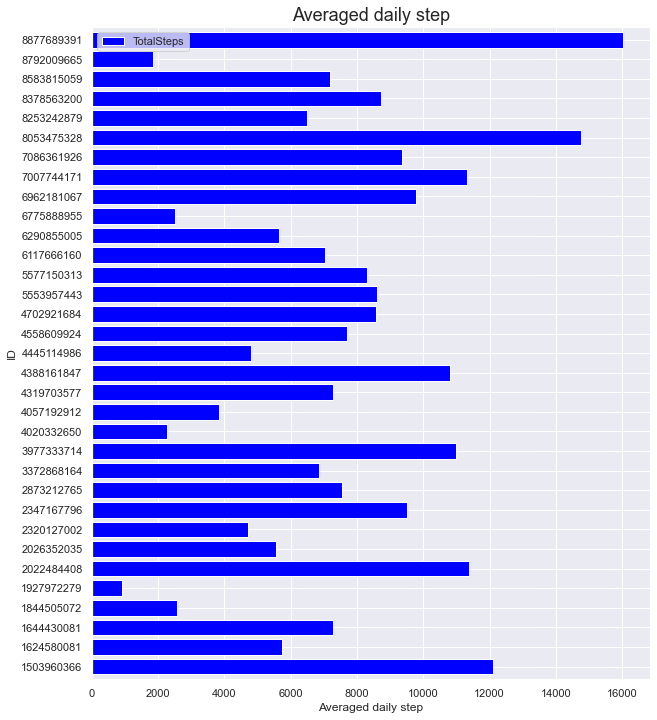

```python
averaged_step = Aggregated_data[['Id','TotalSteps']]
fig, ax = plt.subplots(figsize=(10, 12))
averaged_step.plot( x = 'Id',kind = 'barh',mark_right = True,color=['blue'],width=0.8,ax=ax)
plt.xlabel('Averaged daily step', size=12)
plt.ylabel('ID', size=12)
plt.title('Averaged daily step', size=18)
plt.legend(loc='upper left');
```

Averaged daily steps for most of users (26/33) were less than recommended 10000 daily step for general fitness.

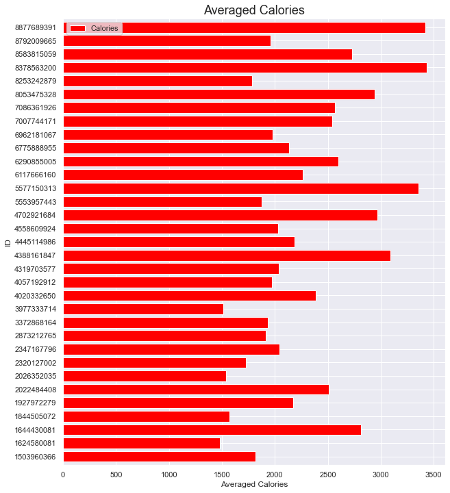

```python
# calculate averaged calories
averaged_calories = Aggregated_data[['Id','Calories']]
fig, ax = plt.subplots(figsize=(10, 12))
averaged_calories.plot(x = 'Id',kind = 'barh',mark_right = True,color=['red'],width=0.8,ax=ax)
plt.xlabel('Averaged Calories', size=12)
plt.ylabel('ID', size=12)
plt.title('Averaged Calories', size=18)
plt.legend(loc='upper left');
```

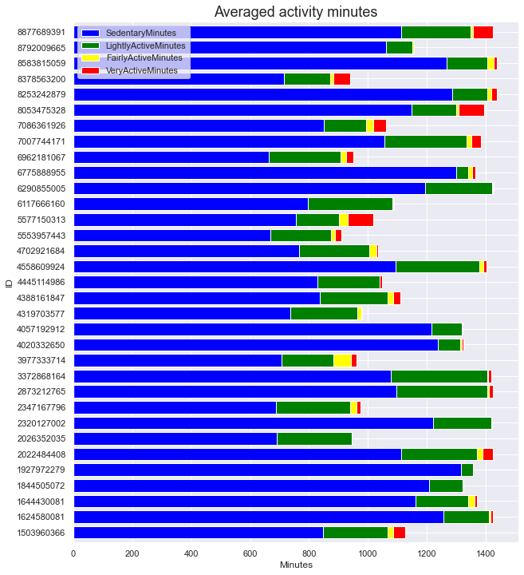

```python
# calculate averaged activity mimutes
active_mins = Aggregated_data[['Id','SedentaryMinutes','LightlyActiveMinutes','FairlyActiveMinutes','VeryActiveMinutes']]
fig, ax = plt.subplots(figsize=(10, 12))
active_mins.plot(x = 'Id',kind = 'barh',stacked = True,mark_right = True,color=['blue','green','yellow','red'],width=0.8,ax=ax)
plt.xlabel('Minutes', size=12)
plt.ylabel('ID', size=12)
plt.title('Averaged activity minutes', size=18)
plt.legend(loc='upper left');
```

26/33 users recorded more than 1000 minutes activity per day (1440 minutes in a day)

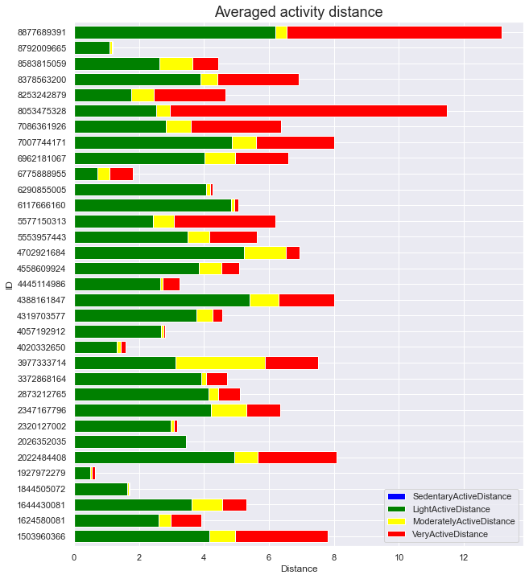

```python
# calculate activity distance
active_dis = Aggregated_data[['Id','SedentaryActiveDistance','LightActiveDistance','ModeratelyActiveDistance','VeryActiveDistance']]
fig, ax = plt.subplots(figsize=(10, 12))
active_dis.plot(x = 'Id',kind = 'barh',stacked = True,mark_right = True,color=['blue','green','yellow','red'],width=0.8,ax=ax)
plt.xlabel('Distance', size=12)
plt.ylabel('ID', size=12)
plt.title('Averaged activity distance', size=18)
plt.legend(loc='lower right');
```

## Aggregating data group by day of week

```python
Aggregated_data_day = cleaned_data.groupby(['Day_of_Week']).mean().reset_index()
Aggregated_data_day
```

|  | Day_of_Week | TotalSteps | TotalDistance | TrackerDistance | LoggedActivitiesDistance | VeryActiveDistance | ModeratelyActiveDistance | LightActiveDistance | SedentaryActiveDistance | VeryActiveMinutes | FairlyActiveMinutes | LightlyActiveMinutes | SedentaryMinutes | Calories | Total_Active_Minutes |
| --- | --- | --- | --- | --- | --- | --- | --- | --- | --- | --- | --- | --- | --- | --- | --- |
| 0 | Friday | 7448.230159 | 5.309921 | 5.302936 | 0.072186 | 1.312937 | 0.483810 | 3.489127 | 0.001825 | 20.055556 | 12.111111 | 204.198413 | 1000.309524 | 2331.785714 | 1236.674603 |
| 1 | Monday | 7780.866667 | 5.552917 | 5.528750 | 0.224552 | 1.537333 | 0.585833 | 3.363083 | 0.002583 | 23.108333 | 14.000000 | 192.058333 | 1027.941667 | 2324.208333 | 1257.108333 |
| 2 | Saturday | 8152.975806 | 5.854677 | 5.854677 | 0.000000 | 1.514597 | 0.677339 | 3.617177 | 0.001048 | 21.919355 | 15.201613 | 207.145161 | 964.282258 | 2354.967742 | 1208.548387 |
| 3 | Sunday | 6933.231405 | 5.027190 | 5.027190 | 0.000000 | 1.488926 | 0.618017 | 2.892314 | 0.000661 | 19.983471 | 14.528926 | 173.975207 | 990.256198 | 2263.000000 | 1198.743802 |
| 4 | Thursday | 7405.836735 | 5.312245 | 5.287415 | 0.129283 | 1.390476 | 0.505170 | 3.283129 | 0.002313 | 19.408163 | 11.959184 | 185.421769 | 961.993197 | 2199.571429 | 1178.782313 |
| 5 | Tuesday | 8125.006579 | 5.832237 | 5.812829 | 0.169054 | 1.613289 | 0.593026 | 3.471053 | 0.001447 | 22.953947 | 14.335526 | 197.342105 | 1007.361842 | 2356.013158 | 1241.993421 |
| 6 | Wednesday | 7559.373333 | 5.488333 | 5.467600 | 0.139588 | 1.633467 | 0.527067 | 3.256333 | 0.001333 | 20.780000 | 13.100000 | 189.853333 | 989.480000 | 2302.620000 | 1213.213333 |

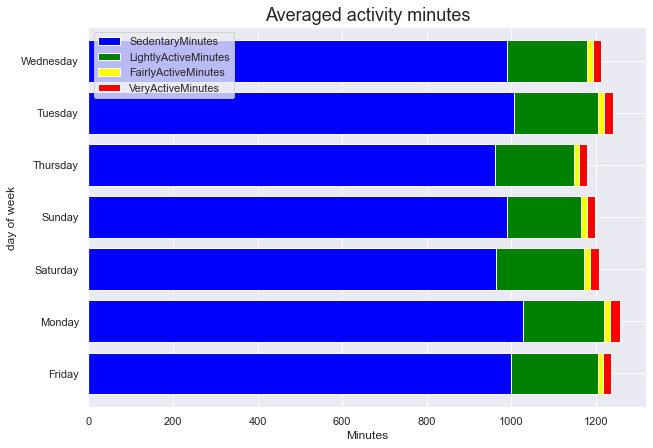

```python
active_mins_day = Aggregated_data_day[['Day_of_Week','SedentaryMinutes','LightlyActiveMinutes','FairlyActiveMinutes','VeryActiveMinutes']]
fig, ax = plt.subplots(figsize=(10, 7))
active_mins_day.plot(x = 'Day_of_Week',kind = 'barh',stacked = True,mark_right = True,color=['blue','green','yellow','red'],width=0.8,ax=ax)
plt.xlabel('Minutes', size=12)
plt.ylabel('day of week', size=12)
plt.title('Averaged activity minutes', size=18)
plt.legend(loc='upper left');
```

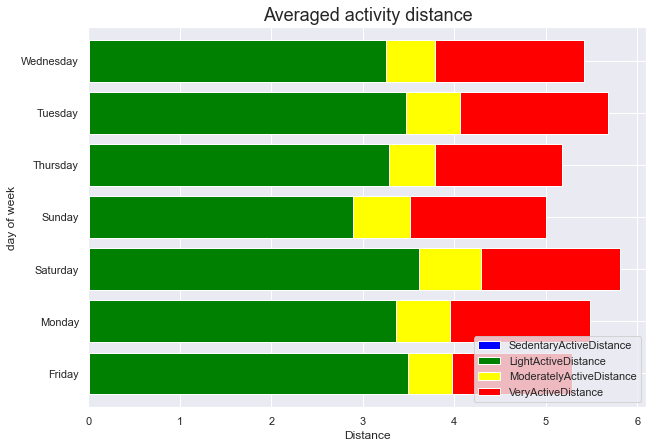

```python
active_dis_day = Aggregated_data_day[['Day_of_Week','SedentaryActiveDistance','LightActiveDistance','ModeratelyActiveDistance','VeryActiveDistance']]
fig, ax = plt.subplots(figsize=(10, 7))
active_dis_day.plot(x = 'Day_of_Week',kind = 'barh',stacked = True,mark_right = True,color=['blue','green','yellow','red'],width=0.8,ax=ax)
plt.xlabel('Distance', size=12)
plt.ylabel('day of week', size=12)
plt.title('Averaged activity distance', size=18)
plt.legend(loc='lower right');
```

## Regression analysis

### Checking for linear assumptions

```python
cleaned_data.columns.values
```

```
array(['Id', 'ActivityDate', 'TotalSteps', 'TotalDistance',
       'TrackerDistance', 'LoggedActivitiesDistance',
       'VeryActiveDistance', 'ModeratelyActiveDistance',
       'LightActiveDistance', 'SedentaryActiveDistance',
       'VeryActiveMinutes', 'FairlyActiveMinutes', 'LightlyActiveMinutes',
       'SedentaryMinutes', 'Calories', 'Day_of_Week',
       'Total_Active_Minutes'], dtype=object)
```

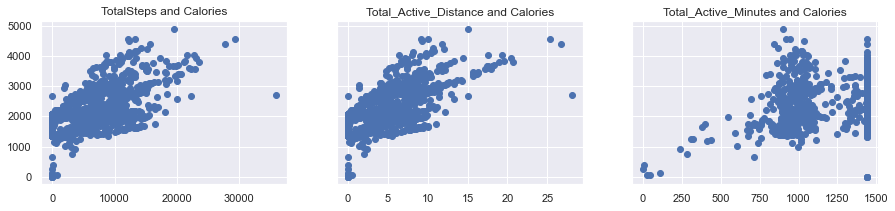

```python
f, (ax1, ax2, ax3) = plt.subplots(1, 3, sharey=True, figsize = (15, 3))
ax1.scatter(cleaned_data['TotalSteps'],cleaned_data['Calories'])
ax1.set_title('TotalSteps and Calories')
ax2.scatter(cleaned_data['TotalDistance'],cleaned_data['Calories'])
ax2.set_title('Total_Active_Distance and Calories')
ax3.scatter(cleaned_data['Total_Active_Minutes'],cleaned_data['Calories'])
ax3.set_title('Total_Active_Minutes and Calories')
```

### Multicollinearity

```python
from statsmodels.stats.outliers_influence import variance_inflation_factor
variables = cleaned_data[['TotalSteps','TotalDistance','Total_Active_Minutes']]
vif = pd.DataFrame()
vif["VIF"] = [variance_inflation_factor(variables.values, i) for i in range(variables.shape[1])]
vif["Features"] = variables.columns
vif
```

|  | VIF | Features |
| --- | --- | --- |
| 0 | 106.257688 | TotalSteps |
| 1 | 98.932423 | TotalDistance |
| 2 | 3.037008 | Total_Active_Minutes |

Variance inflation factor is higher than 10, indicating a multicollinearity problem. Multiple linear regression model might not be appropriate to this study.

### Correlation matrix

```python
# calculate correlation coefficient between parameters
Corr_data = cleaned_data[['TotalSteps','VeryActiveDistance', 'ModeratelyActiveDistance',
       'LightActiveDistance', 'SedentaryActiveDistance',
       'VeryActiveMinutes', 'FairlyActiveMinutes', 'LightlyActiveMinutes',
       'SedentaryMinutes', 'Calories']]
Corr_data.head()
```

|  | TotalSteps | VeryActiveDistance | ModeratelyActiveDistance | LightActiveDistance | SedentaryActiveDistance | VeryActiveMinutes | FairlyActiveMinutes | LightlyActiveMinutes | SedentaryMinutes | Calories |
| --- | --- | --- | --- | --- | --- | --- | --- | --- | --- | --- |
| 0 | 13162 | 1.88 | 0.55 | 6.06 | 0.0 | 25 | 13 | 328 | 728 | 1985 |
| 1 | 10735 | 1.57 | 0.69 | 4.71 | 0.0 | 21 | 19 | 217 | 776 | 1797 |
| 2 | 10460 | 2.44 | 0.40 | 3.91 | 0.0 | 30 | 11 | 181 | 1218 | 1776 |
| 3 | 9762 | 2.14 | 1.26 | 2.83 | 0.0 | 29 | 34 | 209 | 726 | 1745 |
| 4 | 12669 | 2.71 | 0.41 | 5.04 | 0.0 | 36 | 10 | 221 | 773 | 1863 |

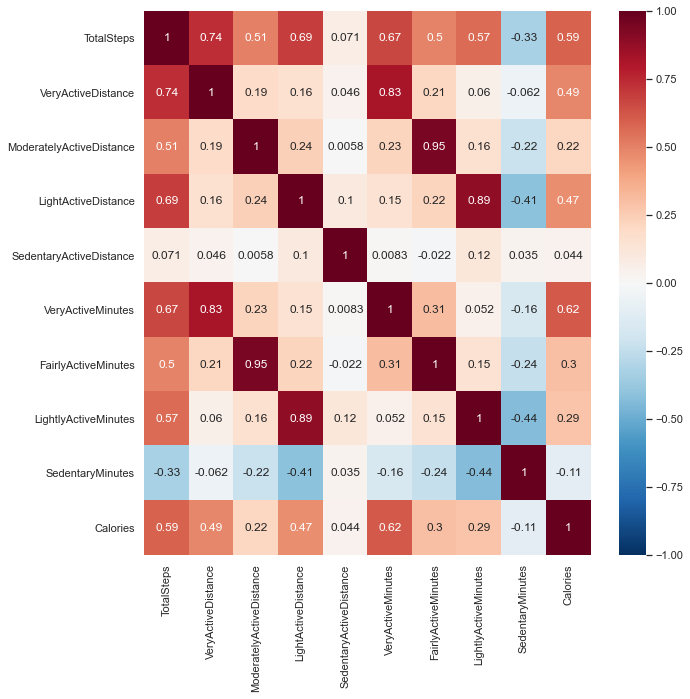

```python
plt.figure(figsize=(10, 10))
sns.heatmap(Corr_data.corr(), cmap = 'RdBu_r', annot = True, vmax = 1, vmin = -1)
```

### Recommendation (based on limited dataset):

1. Fitness smart device has good market prospects. People tends to frequently use device to record their activity, willing to pay more attention to their health issue.
2. Averaged daily activity intensity for most people is not sufficient for general fitness. -Daily step and distance for most people is less than recommended daily step and distance -Most of recorded activity is sedentary mintues, which is negatively correlated with calories. Market advertising could focus on these issues, encouraging customers to pay more attention to their health, using smart decive to track their fitness.